# META-ANALYSIS - Eco-friendly Dataset

Nina

July 2021

# 1 INTRODUCTION

This file describes the analysis of data from the **Eco-friendly** dataset. There are two other analysis files one for the **NIS** dataset and the other for the **General community**, including **Habitat-forming species**.

Here we read in the raw data that has been extracted from suitable studies (see the main body of the manuscript for the selection criteria). We then wrangle the data into a suitable format for constructing our models with **Metafor** (http://www.metafor-project.org/doku.php )

## 1.1 Setting up

```r
#Ensuring starting with a clean environment
rm(list=ls())
#turn off sci notation:
options (scipen = 999)

# ADDING OUTPUT DIRECTORY
# Will give warning if already exists
dir.create(file.path(getwd(), "outputs"))
dir.create(file.path(getwd(), "outputs/eco_friendly"))


#Installing packages and loading existing ones.
# # If installations are necessary:
# install.packages("devtools")
# install.packages("tidyverse")
# install.packages("metafor")
# install.packages("patchwork")
# install.packages("R.rsp")
# devtools::install_github("itchyshin/orchard_plot", subdir = "orchaRd", force = TRUE, build_vignettes = TRUE)
#install.packages("downloadthis")


#libraries
# check conflicts.
library(rotl)
library(ape)
library(metafor)
library(orchaRd)
library(knitr)
library(broom)
library(clubSandwich)
library(multcomp)
library(kableExtra)
library(downloadthis)
library(tidyverse)
```

## 1.2 Loading and checking data file

```r
#import data
meta <- read.csv("./data/Eco_friendly_dataset.csv",
                 header = T,
                 as.is = T)

#changing columns to factors/numeric:
meta <- meta %>% mutate_at (vars(Year,
                                 ReplicatesControl,
                                 ReplicatesTreatment),
                            funs(as.numeric)) %>%
  mutate_at(
    vars(
      Study,
      Parameter,
      Control,
      Control_detail,
      Treatment,
      Treatment_detail,
      Experiment
    ),
    funs(as.factor)
  )

#excluding richness data as insufficient data available (2 studies only)
meta<- subset(meta,Parameter!="Richness")
#removing levels of parameters not present anymore
meta<- meta %>% droplevels()

# showing data in .html version of doc
kable(meta, "html") %>%
  kable_styling("striped", position = "left") %>%
  scroll_box(width = "100%",
             height = "500px")
```

|  | Study | Year | Journal | MeanControl | upperSEControl | SEControl | SDControl | MeanTreatment | upperSETreatment | SETreatment | SDTreatment | ReplicatesControl | ReplicatesTreatment | Parameter | FunctionalGroup | HabitatFormer | Group | Species | SizeoftilestandardisedControlperm2 | SizeofassessedareatandardisedControlperm2 | Reporteddensityperm2 | Typeofmanipulation | Movement | Orientation | Control | Treatment | Control_detail | Treatment_detail | Treatment_detail_MOD | … |
| --- | --- | --- | --- | --- | --- | --- | --- | --- | --- | --- | --- | --- | --- | --- | --- | --- | --- | --- | --- | --- | --- | --- | --- | --- | --- | --- | --- | --- | --- | --- |
| 1 | Anderson1996 | 1996 | Biological Bulletin | 2748.6000000 | 2916.200000 | 167.600000 | 335.2000000 | 854.7490000 | 1139.749000 | 285.000000 | 570.0000000 | 4 | 4 | Density | Invertebrate | Y | Bivalve | Saccostrea glomerata | variable | 0.010000 | 0.010000 | Tile | NA | downward | Concrete | Additive | Concrete | Calcium_hydroxide | Additive_calcium_hydroxide | … |
| 2 | Anderson1996 | 1996 | Biological Bulletin | 1868.7200000 | 2220.670000 | 351.950000 | 703.9000000 | 469.2740000 | 611.732000 | 142.458000 | 284.9160000 | 4 | 4 | Density | Invertebrate | Y | Bivalve | Saccostrea glomerata | variable | 0.010000 | 0.010000 | Tile | NA | downward | Concrete | Additive | Concrete | Calcium_hydroxide | Additive_calcium_hydroxide | … |
| 3 | Anderson1996 | 1996 | Biological Bulletin | 102.1190000 | 108.889000 | 6.770000 | 13.5400000 | 19.0782000 | 24.493900 | 5.415700 | 10.8314000 | 4 | 4 | Density | Invertebrate | Y | Bivalve | Saccostrea glomerata | variable | 0.010000 | 0.010000 | Tile | NA | NA | Concrete | Additive | Concrete | Calcium_hydroxide | Additive_calcium_hydroxide | … |
| 4 | Anderson1996 | 1996 | Biological Bulletin | 104.8630000 | 119.741000 | 14.878000 | 29.7560000 | 107.3430000 | 119.854000 | 12.511000 | 25.0220000 | 4 | 4 | Density | Invertebrate | Y | Bivalve | Saccostrea glomerata | variable | 0.010000 | 0.010000 | Tile | NA | NA | Concrete | Additive | Concrete | Calcium_hydroxide | Additive_calcium_hydroxide | … |
| 5 | Anderson1996 | 1996 | Biological Bulletin | 118.7220000 | 130.472000 | 11.750000 | 23.5000000 | 42.8592000 | 46.577700 | 3.718500 | 7.4370000 | 4 | 4 | Density | Invertebrate | Y | Bivalve | Saccostrea glomerata | variable | 0.010000 | 0.010000 | Tile | NA | NA | Concrete | Additive | Concrete | Calcium_hydroxide | Additive_calcium_hydroxide | … |
| 6 | Anderson1996 | 1996 | Biological Bulletin | 118.1480000 | 122.483000 | 4.335000 | 8.6700000 | 178.8760000 | 204.217000 | 25.341000 | 50.6820000 | 4 | 4 | Density | Invertebrate | Y | Bivalve | Saccostrea glomerata | variable | 0.010000 | 0.010000 | Tile | NA | NA | Concrete | Additive | Concrete | Calcium_hydroxide | Additive_calcium_hydroxide | … |
| 9 | Dennisetal2018 | 2018 | Ecological Engineering | 25.1101000 | 38.766500 | 13.656400 | 30.5366387 | 92.0705000 | 95.815000 | 3.744500 | 8.3729565 | 5 | 5 | PercentageCover | Benthic | N |  | Live cover (%) | 0.0225 | 0.022500 | 0.022500 | Tile | fixed | upfacing | Concrete | Additive | Concrete | Hemp | Additive_hemp | … |
| 10 | Dennisetal2018 | 2018 | Ecological Engineering | 25.1101000 | 38.766500 | 13.656400 | 30.5366387 | 74.0088000 | 82.158600 | 8.149800 | 18.2235068 | 5 | 5 | PercentageCover | Benthic | N |  | Live cover (%) | 0.0225 | 0.022500 | 0.022500 | Tile | fixed | upfacing | Concrete | Additive | Concrete | Shell | Additive_shell | … |
| 11 | Foleyetal2014 | 2014 | Coastal Engineering Proceedings | 97.0000000 | 126.866600 | 29.866600 | 103.4609373 | 91.0000000 | 111.940000 | 20.940000 | 72.5382878 | 12 | 12 | Density | Invertebrate | Y | Coral | Pocillopora damicornis | 0.2215 | 0.221500 | 0.221500 | Tile | fixed | allsides | Concrete | Additive | Concrete | Basalt | Additive_basalt | … |
| 12 | Foleyetal2014 | 2014 | Coastal Engineering Proceedings | 97.0000000 | 126.866600 | 29.866600 | 103.4609373 | 73.8462000 | 88.000000 | 14.153800 | 49.0302014 | 12 | 12 | Density | Invertebrate | Y | Coral | Pocillopora damicornis | 0.2215 | 0.221500 | 0.221500 | Tile | fixed | allsides | Concrete | Additive | Concrete | Limestone | Additive_limestone | … |
| 13 | Foleyetal2014 | 2014 | Coastal Engineering Proceedings | 155.2240000 | 176.119000 | 20.895000 | 93.4452808 | 97.0000000 | 111.940000 | 14.940000 | 66.8137112 | 20 | 20 | Density | Invertebrate | Y | Coral | Coral | 0.2215 | 0.221500 | 0.221500 | Tile | fixed | allsides | Concrete | Additive | Concrete | Basalt | Additive_basalt | … |
| 14 | Foleyetal2014 | 2014 | Coastal Engineering Proceedings | 155.2240000 | 176.119000 | 20.895000 | 93.4452808 | 177.6120000 | 207.895000 | 30.283000 | 135.4296931 | 20 | 20 | Density | Invertebrate | Y | Coral | Coral | 0.2215 | 0.221500 | 0.221500 | Tile | fixed | allsides | Concrete | Additive | Concrete | Limestone | Additive_limestone | … |
| 15 | Foleyetal2014 | 2014 | Coastal Engineering Proceedings | 4.7826100 | 6.066670 | 1.284060 | 5.7424909 | 4.6956500 | 7.000000 | 2.304350 | 10.3053665 | 20 | 20 | Density | Invertebrate | Y | Coral | Coral | 0.2215 | 0.221500 | 0.221500 | Tile | fixed | allsides | Concrete | Additive | Concrete | Basalt | Additive_basalt | … |
| 16 | Foleyetal2014 | 2014 | Coastal Engineering Proceedings | 4.7826100 | 6.066670 | 1.284060 | 5.7424909 | 3.5185200 | 4.608700 | 1.090180 | 4.8754332 | 20 | 20 | Density | Invertebrate | Y | Coral | Coral | 0.2215 | 0.221500 | 0.221500 | Tile | fixed | allsides | Concrete | Additive | Concrete | Limestone | Additive_limestone | … |
| 17 | Hsiungetal2020 | 2020 | Marine Ecology Progress Series | 0.3191490 | NA | NA | NA | 0.3191490 | NA | NA | NA | 12 | 12 | PercentageCover | Benthic | N |  |  | 0.014 | 0.014000 | NA | Tile | fixed | vertical | Concrete | Reduced | Concrete | Carbonated | Reduced_carbonated | … |
| 18 | Hsiungetal2020 | 2020 | Marine Ecology Progress Series | 5.7446760 | NA | NA | NA | 21.7021660 | NA | NA | NA | 12 | 12 | PercentageCover | Benthic | N |  |  | 0.014 | 0.014000 | NA | Tile | fixed | vertical | Concrete | Reduced | Concrete | Carbonated | Reduced_carbonated | … |
| 19 | Hsiungetal2020 | 2020 | Marine Ecology Progress Series | 8.9361660 | NA | NA | NA | 16.9148640 | NA | NA | NA | 12 | 10 | PercentageCover | Benthic | N |  |  | 0.014 | 0.014000 | NA | Tile | fixed | vertical | Concrete | Reduced | Concrete | Carbonated | Reduced_carbonated | … |
| 20 | Hsiungetal2020 | 2020 | Marine Ecology Progress Series | 22.6595640 | NA | NA | NA | 20.4255660 | NA | NA | NA | 12 | 13 | PercentageCover | Benthic | N |  |  | 0.014 | 0.014000 | NA | Tile | fixed | vertical | Concrete | Reduced | Concrete | Carbonated | Reduced_carbonated | … |
| 21 | Hsiungetal2020 | 2020 | Marine Ecology Progress Series | 22.9299520 | NA | NA | NA | 36.4197800 | NA | NA | NA | 12 | 12 | PercentageCover | Benthic | N |  |  | 0.014 | 0.014000 | NA | Tile | fixed | vertical | Concrete | Reduced | Concrete | Carbonated | Reduced_carbonated | … |
| 22 | Hsiungetal2020 | 2020 | Marine Ecology Progress Series | 29.2993430 | NA | NA | NA | 33.0246400 | NA | NA | NA | 12 | 12 | PercentageCover | Benthic | N |  |  | 0.014 | 0.014000 | NA | Tile | fixed | vertical | Concrete | Reduced | Concrete | Carbonated | Reduced_carbonated | … |
| 23 | Hsiungetal2020 | 2020 | Marine Ecology Progress Series | 72.9300400 | NA | NA | NA | 66.9752800 | NA | NA | NA | 6 | 5 | PercentageCover | Benthic | N |  |  | 0.014 | 0.014000 | NA | Tile | fixed | vertical | Concrete | Reduced | Concrete | Carbonated | Reduced_carbonated | … |
| 24 | Hsiungetal2020 | 2020 | Marine Ecology Progress Series | 56.3694200 | NA | NA | NA | 59.5679400 | NA | NA | NA | 12 | 10 | PercentageCover | Benthic | N |  |  | 0.014 | 0.014000 | NA | Tile | fixed | vertical | Concrete | Reduced | Concrete | Carbonated | Reduced_carbonated | … |
| 25 | Hsiungetal2020 | 2020 | Marine Ecology Progress Series | 0.3333333 | NA | NA | 0.5163978 | 1.6666667 | NA | NA | 4.0824829 | 6 | 6 | Density | Benthic | N |  |  | 0.014 | 0.014000 | NA | Tile | fixed | vertical | Concrete | Reduced | Concrete | Carbonated | Reduced_carbonated | … |
| 26 | Hsiungetal2020 | 2020 | Marine Ecology Progress Series | 1.0000000 | NA | NA | 1.2649111 | 0.5000000 | NA | NA | 0.8366600 | 6 | 6 | Density | Benthic | N |  |  | 0.014 | 0.014000 | NA | Tile | fixed | vertical | Concrete | Reduced | Concrete | Carbonated | Reduced_carbonated | … |
| 27 | Hsiungetal2020 | 2020 | Marine Ecology Progress Series | 0.5000000 | NA | NA | 0.5477226 | 0.1666667 | NA | NA | 0.4082483 | 6 | 6 | Density | Benthic | N |  |  | 0.014 | 0.014000 | NA | Tile | fixed | vertical | Concrete | Reduced | Concrete | Carbonated | Reduced_carbonated | … |
| 28 | Hsiungetal2020 | 2020 | Marine Ecology Progress Series | 45.6666667 | NA | NA | 30.3754287 | 60.6666667 | NA | NA | 27.5439043 | 6 | 6 | Density | Benthic | N |  |  | 0.014 | 0.014000 | NA | Tile | fixed | vertical | Concrete | Reduced | Concrete | Carbonated | Reduced_carbonated | … |
| 29 | Hsiungetal2020 | 2020 | Marine Ecology Progress Series | 51.1666667 | NA | NA | 45.3846523 | 110.5000000 | NA | NA | 90.4317422 | 6 | 6 | Density | Benthic | N |  |  | 0.014 | 0.014000 | NA | Tile | fixed | vertical | Concrete | Reduced | Concrete | Carbonated | Reduced_carbonated | … |
| 30 | Hsiungetal2020 | 2020 | Marine Ecology Progress Series | 89.3333333 | NA | NA | 75.7434266 | 76.1666667 | NA | NA | 92.3978716 | 6 | 6 | Density | Benthic | N |  |  | 0.014 | 0.014000 | NA | Tile | fixed | vertical | Concrete | Reduced | Concrete | Carbonated | Reduced_carbonated | … |
| 31 | Hsiungetal2020 | 2020 | Marine Ecology Progress Series | 3.3333333 | NA | NA | 4.1311822 | 10.3333333 | NA | NA | 4.3204938 | 6 | 6 | Density | Benthic | N |  |  | 0.014 | 0.014000 | NA | Tile | fixed | vertical | Concrete | Reduced | Concrete | Carbonated | Reduced_carbonated | … |
| 32 | Hsiungetal2020 | 2020 | Marine Ecology Progress Series | 94.0000000 | NA | NA | 23.7402612 | 75.8333333 | NA | NA | 17.4976189 | 6 | 6 | Density | Benthic | N |  |  | 0.014 | 0.014000 | NA | Tile | fixed | vertical | Concrete | Reduced | Concrete | Carbonated | Reduced_carbonated | … |

[output cut: 106 more lines]

```r
# this is the data we want to make available:
meta %>%
  download_this(
    output_name = "Eco_friendly_dataset",
    output_extension = ".csv",
    button_type = "default",
    has_icon = T,
    icon = "fa fa-save",
    csv2 = F
  )
```

## 1.3 Creating Reference Columns

Checking that there are sufficient identifier and reference columns for our random effects:

- Adding **Effect ID** which represents each unique datapoint in the database.
- **Study** already exists - showing data points which come from the same study.
- We also add **experiment ID**, which shows which datapoints come from the same experiment. We do this by grouping by study, location, and other reference columns that identify unique experiments within the same study.
- Duration is not included as we are incorporating repeated measures time points
- and therefore is not a unique identifier for experiment ID.

These are mostly important for the random effects and independence components of the analysis.

```r
# create column with unique data points.. row names essentially
meta<- rowid_to_column(meta, "Effect_ID")
meta$Effect_ID <-as.factor(meta$Effect_ID)

#need an ID to define experiment groupings
Exp_ID <- meta %>%
  group_by(Study,
           Experiment) %>%
  summarise(num_instances = n())

# row ID for exp number
Exp_ID <- rowid_to_column(Exp_ID, "Exp_ID")
# now join back to main dataset based based on this number:
meta <- left_join(meta,
                  Exp_ID,
                  by = c("Study",
                         "Experiment"))

meta$Exp_ID <- as.factor(meta$Exp_ID)

rm(Exp_ID) # leaving in for now, to check numbers
```

## 1.4 Definitions:

**Parameter:** these are

```
## [1] "Density"         "PercentageCover"
```

**Treatment:** these are substrates that are considered ARTIFICIAL and are either completely manufactured or have undergone a some kind of transformative process:

```r
levels(meta$Treatment)
```

```
## [1] "Additive" "Reduced"
```

Detailed breakdown of included artificial materials:

Reduced (details)

```r
meta %>%
  dplyr::filter(Treatment =="Reduced") %>%
  { unique(.$Treatment_detail) }
```

```
## [1] Carbonated Matrix M1  Matrix M2  Matrix M3  Matrix M4  Matrix M5
## 15 Levels: Basalt Calcium_hydroxide Carbonated Coral ... Shell
```

Additive (details)

```r
meta %>%
  dplyr::filter(Treatment =="Additive") %>%
  { unique(.$Treatment_detail) }
```

```
## [1] Calcium_hydroxide
## [2] Hemp
## [3] Shell
## [4] Basalt
## [5] Limestone
## [6] Coral_rubble
## [7] Coral_rubble_encrusted_with_coralline_algae
## [8] Coral_rubble_covered_with_coralline_algae
## [9] Coral
## 15 Levels: Basalt Calcium_hydroxide Carbonated Coral ... Shell
```

# 2 DATA WRANGLING

## 2.1 Dealing with zeros

The method we’re using for ESCALC - the log ratio of means, cannot handle zeros in the denominator/numerator as you can’t take a log of zero.

To deal with zeros we can either, run the model:

- with the zeros removed, or
- with the zero values having 0.5 added to them.

We prefer to keep the data - rather than just remove the zeros - as the means or SDs of controls and treatments that contain zeros, make up ~10% of the data.

Here we add a constant of 0.5 to SDs of control and treatment, and means of control and treatment.

```r
#first lets see how many zeros there are:
meta_zeros <- meta %>%
        filter(MeanControl==0.0 | MeanTreatment==0.0 | SDControl==0.0 | SDTreatment ==0.0)
# 13 rows with zeros in means or SDs

# Removing Zeros - this works, but not used
# meta_no_zeros <- meta[meta$MeanControl != 0, ]
# meta_no_zeros <- meta_no_zeros[meta_no_zeros$MeanTreatment != 0, ]
# meta_no_zeros <- meta_no_zeros[meta_no_zeros$SDControl != 0, ]
# meta_no_zeros <- meta_no_zeros[meta_no_zeros$SDTreatment != 0, ]
# 123 from 136 - removed 13

#meta <- meta_no_zeros  # the option for just removing all rows with zeros.

# there are 13 instances in total of 136 possibles.
# this is 9.56% - we would prefer to retain the data, and therefore
# have added 0.5 to everything.

meta_05 <- meta %>%
  mutate_at(vars(c(
    "SDControl", "SDTreatment", "MeanControl", "MeanTreatment"
  )),
  ~ . + 0.5)
#using the 0.5 option..(leaves in Nas)
meta <- meta_05
rm(meta_05, meta_zeros) #clearing variables no longer needed.

# check output
#head(meta)
```

## 2.2 Dropping or replacing SD blanks

Previously we left blank SDs out, but this also removed a lot of data. A better practice is to use the function of the log of the SD and the control or treatment means to replace the missing data.

We fill the missing SDs for density and percentage cover combined.

Checks: How many studies/datapoints have missing SDs?

```r
#datapoints with missing SDs:
meta_gaps <- meta %>% filter(is.na(SDControl) & is.na(SDTreatment))
#using only complete pairs for developing the function
meta_no_gaps <- meta %>% filter(!is.na(SDControl) & !is.na(SDTreatment))
```

There are **68** datapoints missing SDs out of **136** in the full dataset. This equates to **50** % of datapoints.

There are **2** studies with gaps in SDs from a total of **9** studies in the dataset. This equates to **22.2222222**%. Less than ~20-30% is considered OK.

The studies with missing SDs are:

```
##    unique(meta_gaps$Study)
## 1           Hsiungetal2020
## 2 PerkolFinkelandSella2014
```

The distribution of missing SD is as follows:

```
##
##         Density PercentageCover
##               0              68
```

```
##
##         Density PercentageCover
##              66              70
```

```
##
##         Density PercentageCover
##         0.00000        97.14286
```

```r
# #removing levels of parameters not present anymore
meta_gaps<- meta_gaps %>% droplevels()
meta_no_gaps<- meta_no_gaps %>% droplevels()
```

The parameters that at missing SDs include: **PercentageCover**.

```r
# showing data in .html version of doc
kable(a, "html") %>%
  kable_styling("striped", position = "left") %>%
  scroll_box(width = "100%",
             height = "100%")
```

| names | Density | PercentageCover |
| --- | --- | --- |
| No. datapoints missing SD | 0 | 68.00000 |
| Total no. datapoints | 66 | 70.00000 |
| Percentage datapoints missing SD | 0 | 97.14286 |

```r
rm(a)
```

Filling in the missing SDs for both the controls and the treatments, separately:

### 2.2.1 Control:

```r
#Origninal data
plot(meta_no_gaps$MeanControl, meta_no_gaps$SDControl)
```

```r
#Logged data
# plotting trend lines per parameter and overall trend line.
p05 <-
  ggplot(meta_no_gaps, aes(x = log10(MeanControl) , y = log10(SDControl))) +
  geom_point(aes(colour = Parameter)) +
  stat_smooth (method = "lm", aes (colour = Parameter), se = F) +
  stat_smooth(method = "lm", aes(), se = F)
ggsave(filename = "./outputs/eco_friendly/control_mean_sd.tiff")

# find the equation of the line:
#lm(y~x)
#must log10 the data as with the plot.
reg_2_05 <- lm(log10(meta_no_gaps$SDControl) ~log10(meta_no_gaps$MeanControl))
# check this against the plot
plot(log10(meta_no_gaps$MeanControl), log10(meta_no_gaps$SDControl))
abline(reg_2_05, col = "blue")
```

```r
#model results summary
coef(reg_2_05)
paste('log10(SD) =',
      coef(reg_2_05)[[2]],
      '* log10(mean)',
      '+',
      coef(reg_2_05)[[1]])

# using the results from the lm() to "predict" or fill the gaps in the original
#data frame:
meta <- meta %>%
  mutate(SDControl = ifelse(is.na(SDControl),
                            10 ^ ((
                              coef(reg_2_05)[[2]] * log10(MeanControl)
                            ) +
                              coef(reg_2_05)[[1]]), SDControl))
# comparative plots
#no gaps
meta_no_gaps %>%
  ggplot(aes(x = MeanControl, y = SDControl)) +
  geom_point()
```

```r
ggsave(filename = "./outputs/eco_friendly/Control_original.tiff")
#gaps
meta %>%
  ggplot(aes(x = MeanControl, y = SDControl)) +
  geom_point()
```

```r
ggsave(filename = "./outputs/eco_friendly/Control_filled.tiff")

# comparative plots - logged
#no gaps logged
meta_no_gaps %>%
  ggplot(aes(x = log10(MeanControl), y = log10(SDControl))) +
  geom_point()
```

```r
ggsave(filename = "./outputs/eco_friendly/Control_original_log.tiff")

rm(p05)
```

Filled Gaps:

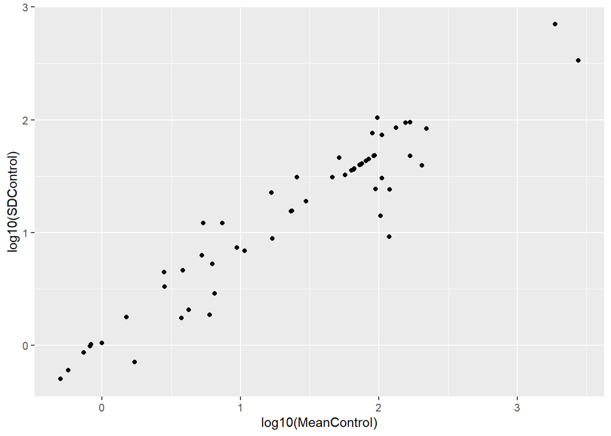

```r
#gaps logged
meta %>%
  ggplot(aes(x = log10(MeanControl), y = log10(SDControl))) +
  geom_point()
```

```r
ggsave(filename = "./outputs/eco_friendly/Control_filled_log.tiff")
```

### 2.2.2 Treatment:

```r
#Origninal data
# plot(x,y)
plot(meta_no_gaps$MeanTreatment, meta_no_gaps$SDTreatment)
```

```r
#Logged data
# plotting trend lines per parameter and overall trend line.
meta_no_gaps %>%
  ggplot(aes(x = log10(MeanTreatment) , y = log10(SDTreatment))) +
  geom_point(aes(colour = Parameter)) +
  stat_smooth (method = "lm", aes (colour = Parameter), se = F) +
  stat_smooth(method = "lm", aes(), se = F)
```

```r
ggsave(filename = "./outputs/eco_friendly/Treatment_mean_sd.tiff")
# some outliers - but mostly looks ok.

# find the equation of the line:
#lm(y~x)
reg_3_05 <-
  lm(log10(meta_no_gaps$SDTreatment) ~ log10(meta_no_gaps$MeanTreatment))
plot(log10(meta_no_gaps$MeanTreatment),
     log10(meta_no_gaps$SDTreatment))
abline(reg_3_05, col = "blue")
```

```r
#model results summary
coef(reg_3_05)
paste('log10(SD) =',
      coef(reg_3_05)[[2]],
      '* log10(mean)',
      '+',
      coef(reg_3_05)[[1]])

#filling gaps in TREATMENT SD
#Accepting changes:
meta <- meta %>%
  mutate(SDTreatment = ifelse(is.na(SDTreatment),
                              10 ^ ((
                                coef(reg_3_05)[[2]] * log10(MeanTreatment)
                              ) +
                                coef(reg_3_05)[[1]]), SDTreatment))
#Checking changes by plotting
#comparative plots
#no gaps
meta_no_gaps %>%
  ggplot(aes(x = MeanTreatment, y = SDTreatment)) +
  geom_point()
```

```r
ggsave(filename = "./outputs/eco_friendly/Treatment_original.tiff")
#gaps
meta %>%
  ggplot(aes(x = MeanTreatment, y = SDTreatment)) +
  geom_point()
```

```r
ggsave(filename = "./outputs/eco_friendly/Treatment_filled.tiff")

# comparative plots - logged
#no gaps logged
meta_no_gaps %>%
  ggplot(aes(x = log10(MeanTreatment), y = log10(SDTreatment))) +
  geom_point()
```

```r
ggsave(filename = "./outputs/eco_friendly/Treatment_original_log.tiff")
```

Filled Gaps

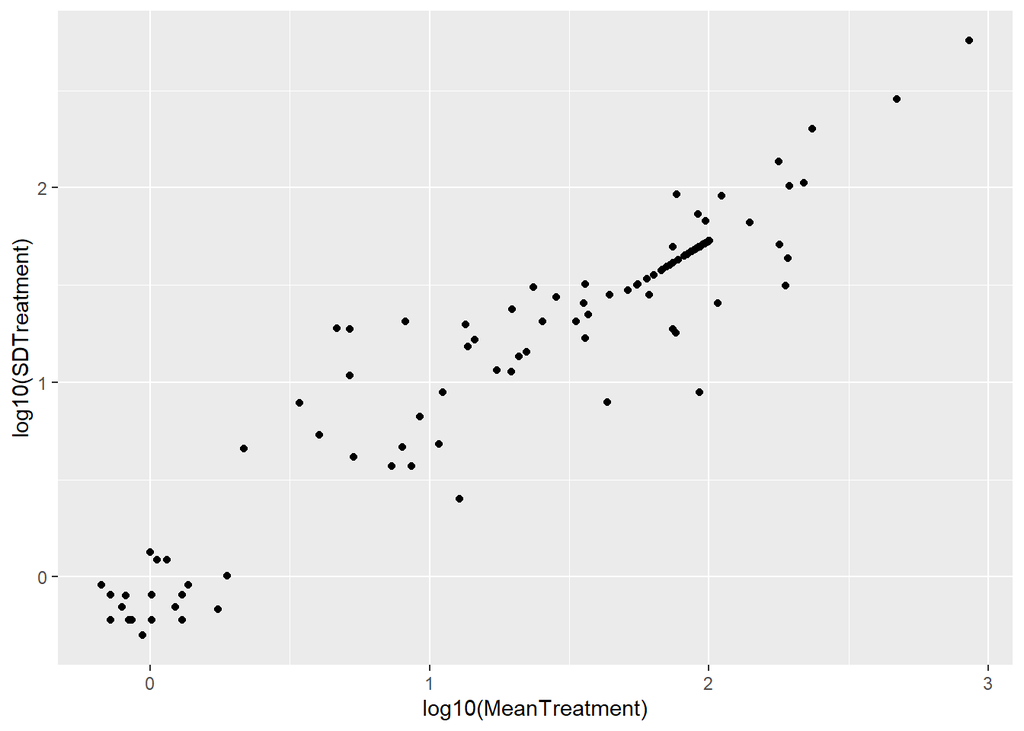

```r
#gaps logged
meta %>%
  ggplot(aes(x = log10(MeanTreatment), y = log10(SDTreatment))) +
  geom_point()
```

```r
ggsave(filename = "./outputs/eco_friendly/Treatment_filled_log.tiff")
```

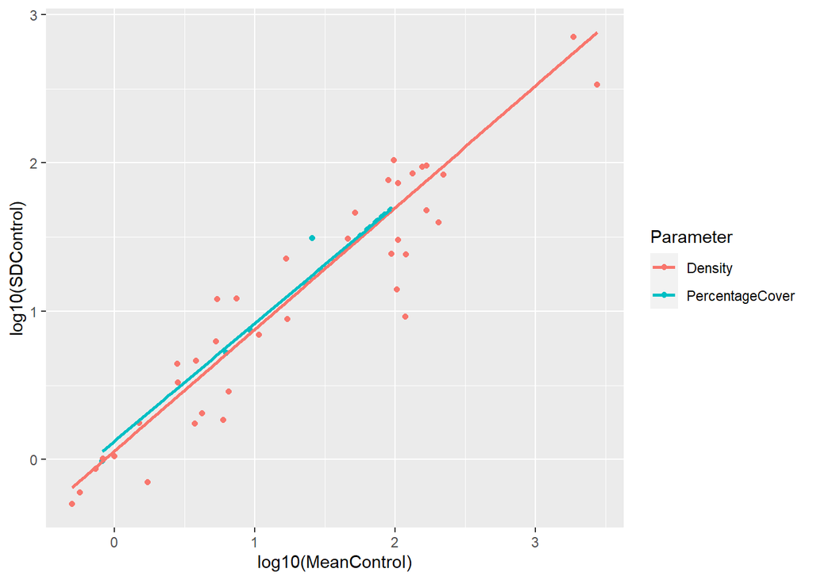

```r
p <-
  ggplot(meta, aes(x = log10(MeanControl) , y = log10(SDControl),)) +
  geom_point(aes(colour = Parameter))
p + stat_smooth (method = "lm", aes (colour = Parameter), se = F)
```

Filled gaps for all **TREATMENT/Artificial** materials

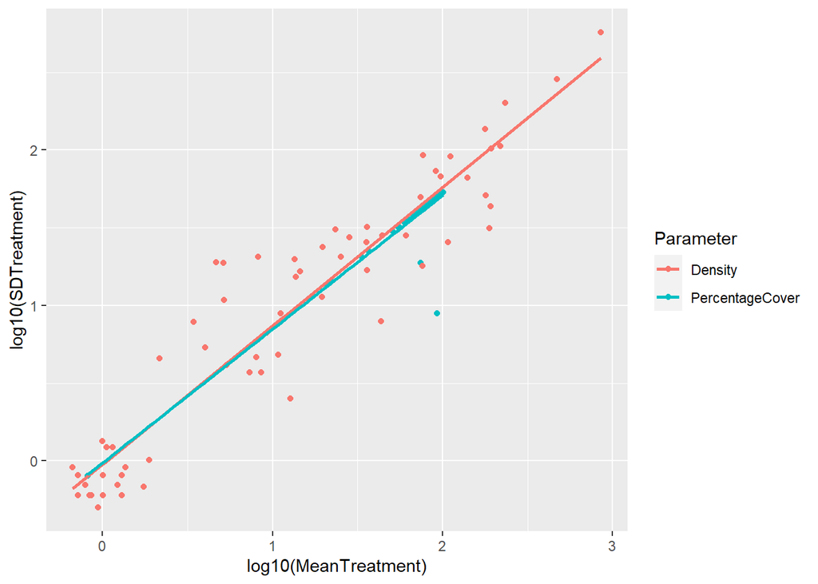

```r
p <-
  ggplot(meta, aes(x = log10(MeanTreatment) , y = log10(SDTreatment),)) +
  geom_point(aes(colour = Parameter))
p + stat_smooth (method = "lm", aes (colour = Parameter), se = F)
```

Removing excess variables

```r
rm(reg_2_05,reg_3_05,meta_gaps,meta_no_gaps,p)
```

##Studies per Exp_ID to check for sufficient replication

```r
#checking how many studies are in each level:
Treatment_levels<-levels(meta$Treatment)
Treatment_ExpID<- map(Treatment_levels, ~length(unique(meta$Exp_ID[meta$Treatment ==.])))

#checking how many studies are in each level:
FunctionalGroup_levels<-levels(meta$FunctionalGroup)
FunctioalGroup_ExpID<- map(FunctionalGroup_levels, ~length(unique(meta$Exp_ID[meta$FunctionalGroup ==.])))

#create interaction of treatment and functional group
meta$T_F <- paste(meta$Treatment, meta$FunctionalGroup, sep="_")
meta$T_F <- as.factor(meta$T_F)

#checking how many studies are in each level:
T_F_levels<-levels(meta$T_F)
T_F_Exp_ID<- map(T_F_levels, ~length(unique(meta$Exp_ID[meta$T_F ==.])))
#insufficient replication to incorporate the interaction in the analyses
```

## 2.3 Accounting for non-independence

Partitioning the “n”

Accounting for instances where the experimental error is shared between datapoints rather than being independent is an important step. This is because the meta-regression models we’re using assume independence, unless told otherwise.

Here we partition the replicates of the controls and treatments depending on whether they are shared or not.

- when grouped by control.. how many treatment TYPES are there? (ie cases of shared treatments)
- when grouped by treatment.. how many control TYPES are there? (ie cases of shared controls)

Here, only partitioning based on treatment is required as concrete is the only control.

Partitioning based on Treatment:

```r
#Adding in a new column to the dataset for the reduced replicates per control

meta <- meta %>%
  group_by(Exp_ID) %>%
  mutate(unique_types = n_distinct(Treatment_detail))


# Partition the N based on these results:
meta <- meta %>%
  mutate(reducedReplicatesControl = (ReplicatesControl / unique_types))
```

# 3 ESCALC AND VCV

Have now switched Control and Treatment to ensure the Orchard plot is still inline with the standard meta plots. This means we now have:

Group 1 = TREATMENT - Eco-friendly substrates Group 2 = CONTROL - Concrete (Therefore +ve results favour treatments, and -ve results favour control)

Calculating the effect sizes and outcome measures. We’re using the Risk Ratio - in the form of Ratio of Means, and we will take the log of this ratio - centered around zero.

```r
# we originally used the ESCALC function from metafor here, however a recent
# update has meant that sample sizes (n) or less than one create an error.
# As our sample size is partitioned to account for non-independence, we have
# had to write the orignal version of escalc manually.
# We have retained the original escalc in the comments in case that is of interest.

# Escalc funtion:
# meta <-  escalc(
#           m1i = meta$MeanTreatment,
#           sd1i = meta$SDTreatment,
#           n1i = meta$ReplicatesTreatment,
#           m2i = meta$MeanControl,
#           sd2i = meta$SDControl,
#           n2i = meta$reducedReplicatesControl,
#           measure = "ROM",
#           append = TRUE,
#           data = meta
#         )

lnRR <- function(CMean, CSD, CN, EMean, ESD, EN){
yi<-log( EMean / CMean)
vi <- CSD^2 / (CN * CMean^2) + ESD^2 / (EN * EMean^2)
print(data.frame(yi,vi))
}

meta.lnRR <- lnRR(
  CMean = meta$MeanControl,
  CSD = meta$SDControl,
  CN = meta$reducedReplicatesControl,
  EMean = meta$MeanTreatment,
  ESD = meta$SDTreatment,
  EN = meta$ReplicatesTreatment)

meta<- cbind(meta, meta.lnRR)
```

# 4 VCV MATRIX

To account for multiple timepoints coming from the same tile/experiment this calculates a matrix which is used as “V” in the models that follow. For the models the “Yi” comes from Escalc, and the “VI” will come from this V.

This VCV matrix uses **Study** as a clustering parameter, which will then account for all non-independence in the experiments within study - in this case that includes, repeated measures sampling **AND** multiple measures from the same experiment (measurement parameters).

```r
V <-
  impute_covariance_matrix(
    vi = meta$vi,
    cluster = meta$Study,
    r = 0.5,
    return_list = F
  )


#This is just a test of the vcv functionality.
# The vcv is calculated for each model or group at the modelling stage.
V.check <-
  impute_covariance_matrix(
    vi = meta$vi,
    cluster = meta$Study,
    r = 0.5,
    return_list = F
  )

# using the return_list = F option is not recommended when the elements aren't
# ordered... which could cause issues, there's a check to see that they are correct.

#all.equal(meta$vi, diag(V.check))
```

# 5 MODELS

Now we add the models in a stepwise fashhion

The overarching method followed is:

1. Run the most simple version of the model. Without moderators (but with random effects) Check the heterogeneity: a significant amount of heterogeneity means that although you may have a main trend in your effect size, there is STILL a lot of unexplained variability in the effect size . Heterogeneity is generally caused by the different ways in which studies are undertaken. There is a rule of thumb to use a as a threshold for when to continue/stop (>60% is moderate, >70% is high).
2. Add moderators to your model - do this one by one and in each case you can check the effect on the heterogeneity. Showing that the variability of the main effect was moderated by.. The moderators could be useful predictors of the variability in the effect of natural vs artificial substrates on the abundance.
3. Finally add all moderators and random effects into one model and the amount of heterogeneity remaining should NOT be significant. This also serves to check the robustness of the moderators.

SIMPLE MODEL

Steps:

- simple model, then add treatment, then control, then durations all separately
- in each case calculate the I2, then the R2 (model fit).
- Then plot an orchard plot - precision shown by size of ‘fruit’.
- Then plot a caterpillar plot - mean effect size plus CIs for each study
- Both plots have 95% confidence intervals that support the mean effect size, as well as prediction intervals which predict the range of effects that may be observed.

Setting dpi value for plots

```r
plot_dpi <- 300
#suggestions: 320 - retina, 300 - print, 72 - screen
```

## 5.1 Simple model

```r
rom.simple <- rma.mv(
  yi,
  V,
  random = list( ~ 1 | Study,
                 ~ 1 | Exp_ID,
                 ~ 1 | Effect_ID,
                 ~ 1 | Parameter),
  method = "REML",
  data = meta,
  control = list(optimizer = "optim")
)


sum <- summary(rom.simple)
sum_I2 <- i2_ml(rom.simple, method = "ns")
sum_R2 <- r2_ml(rom.simple)

res.simple <-
  data.frame(
    effectname = attr(sum$beta, "dimnames")[[1]],
    beta = as.numeric(sum$beta),
    percentage_increase_or_decrease_on_Ecofriendly = (exp(sum$beta)-1)*100,
    real.effect.value_exp_beta = exp(sum$beta),
    pval = sum$pval,
    ci.lb = sum$ci.lb,
    ci.ub = sum$ci.ub,
    I2_total = sum_I2[[1]] * 100,
    I2_study = sum_I2[[2]] * 100,
    I2_Exp_ID = sum_I2[[3]] * 100,
    I2_Effect_ID = sum_I2[[4]] * 100,
    I2_Parameter = sum_I2[[5]] * 100,
    R2_marginal_fixed = sum_R2[[1]] * 100,
    R2_conditional_fixed_random = sum_R2[[2]] * 100,
    AIC = rom.simple$fit.stats$REML[3]
  )

res_simple_df <- bind_rows(res.simple)
write.csv(res_simple_df, file = "./outputs/eco_friendly/summ_simple.csv")

# show as kable table:
res_simple_df %>%
  kable("html", digits = 3) %>%
  kable_styling("striped", position = "left") %>%
  scroll_box(width = "100%",
             height = "100%")
```

|  | effectname | beta | percentage_increase_or_decrease_on_Ecofriendly | real.effect.value_exp_beta | pval | ci.lb | ci.ub | I2_total | I2_study | I2_Exp_ID | I2_Effect_ID | I2_Parameter | R2_marginal_fixed | R2_conditional_fixed_random | AIC |
| --- | --- | --- | --- | --- | --- | --- | --- | --- | --- | --- | --- | --- | --- | --- | --- |
| intrcpt | intrcpt | 0.044 | 4.545 | 1.045 | 0.796 | -0.292 | 0.381 | 62.366 | 26.013 | 28.864 | 7.487 | 0.002 | 0 | 99.997 | 185.473 |

```r
# expecting R2_marginal to be zero as there are no moderators
#so no fixed factors to investigate.

simp_orch <-
  orchard_plot(rom.simple, mod = "Int", xlab = "Ratio of means") +
  scale_y_discrete(labels = c("Intrcpt" = "Overall")) +
  theme(
    text = element_text(size = 20, colour = "black"),
    axis.text.y = element_text(size = 20, colour = "black")
  ) +
  theme(
    legend.direction = "horizontal",
    legend.title = element_text(size = 20, colour = "black"),
    legend.text = element_text(size = 20, colour = "black")
  )


ggsave(
  simp_orch,
  file = "./outputs/eco_friendly/simp_orch.tiff",
  dpi = plot_dpi,
  width = 8,
  height = 8
)
ggsave(
  simp_orch,
  file = "./outputs/eco_friendly/simp_orch.pdf",
  dpi = plot_dpi,
  width = 8,
  height = 8
)

simp_cat <-
  caterpillars(rom.simple, mod = "Int", xlab = "Ratio of means")
ggsave(simp_cat, file = "./outputs/eco_friendly/simp_cat.tiff", dpi = plot_dpi)
```

## 5.2 Adding Mod: TREATMENT

```r
rom.Treatment <- rma.mv(
  yi,
  V,
  mods = ~ Treatment - 1,
  random = list(~ 1 | Study,
                ~ 1 | Exp_ID,
                ~ 1 | Effect_ID,
                ~ 1 | Parameter),
  method = "REML",
  data = meta,
  control = list(optimizer = "optim")
)

sum <- summary(rom.Treatment)
sum_I2 <- i2_ml(rom.Treatment, method = "ns")
sum_R2 <- r2_ml(rom.Treatment)

res.Treatment <-
  data.frame(
    effectname = attr(sum$beta, "dimnames")[[1]],
    beta = as.numeric(sum$beta),
    percentage_increase_or_decrease_on_Ecofriendly = (exp(sum$beta) -
                                                        1) * 100,
    real.effect.value_exp_beta = exp(sum$beta),
    pval = sum$pval,
    ci.lb = sum$ci.lb,
    ci.ub = sum$ci.ub,
    I2_total = sum_I2[[1]] * 100,
    I2_study = sum_I2[[2]] * 100,
    I2_Exp_ID = sum_I2[[3]] * 100,
    I2_Effect_ID = sum_I2[[4]] * 100,
    I2_Parameter = sum_I2[[5]] * 100,
    R2_marginal_fixed = sum_R2[[1]] * 100,
    R2_conditional_fixed_random = sum_R2[[2]] * 100,
    Moderator_significance_stat = sum$QM,
    Moderator_significance_pval = sum$QMp,
    AIC = rom.Treatment$fit.stats$REML[3]
  )



res_Treatment_df <- bind_rows(res.Treatment)
write.csv(res_Treatment_df, file = "./outputs/eco_friendly/summ_Treatment.csv")

Treatment_orch <-
  orchard_plot(rom.Treatment, mod = "Treatment", xlab = "Ratio of means") +
  theme(axis.text.y = element_text(angle = 0, hjust = 1)) +
  ggtitle("Eco-friendly") +
  theme(plot.title = element_text(size = 14, face = "bold"),
        text = element_text(size = 12),
        axis.text.y = element_text(size = 12))

ggsave(Treatment_orch, file = "./outputs/eco_friendly/Treatment_orch.tiff", dpi = plot_dpi)

Treatment_cat <-
  caterpillars(rom.Treatment, mod = "Treatment", xlab = "Ratio of means")
ggsave(Treatment_cat, file = "./outputs/eco_friendly/Treatment_cat.tiff", dpi = plot_dpi)

# checking contrasts:
summary(glht(
  rom.Treatment,
  linfct = c("TreatmentAdditive - TreatmentReduced = 0")
))
```

Summary of results:

```r
res.Treatment %>%
  kable("html", digits = 3) %>%
  kable_styling("striped", position = "left") %>%
  scroll_box(width = "100%",
             height = "100%")
```

|  | effectname | beta | percentage_increase_or_decrease_on_Ecofriendly | real.effect.value_exp_beta | pval | ci.lb | ci.ub | I2_total | I2_study | I2_Exp_ID | I2_Effect_ID | I2_Parameter | R2_marginal_fixed | R2_conditional_fixed_random | Moderator_significance_stat | Moderator_significance_pval | AIC |
| --- | --- | --- | --- | --- | --- | --- | --- | --- | --- | --- | --- | --- | --- | --- | --- | --- | --- |
| TreatmentAdditive | TreatmentAdditive | 0.105 | 11.019 | 1.110 | 0.646 | -0.342 | 0.551 | 66.075 | 32.756 | 26.571 | 6.648 | 0.101 | 1.329 | 99.85 | 0.224 | 0.894 | 184.119 |
| TreatmentReduced | TreatmentReduced | -0.039 | -3.813 | 0.962 | 0.908 | -0.701 | 0.623 | 66.075 | 32.756 | 26.571 | 6.648 | 0.101 | 1.329 | 99.85 | 0.224 | 0.894 | 184.119 |

Plot for Treatment

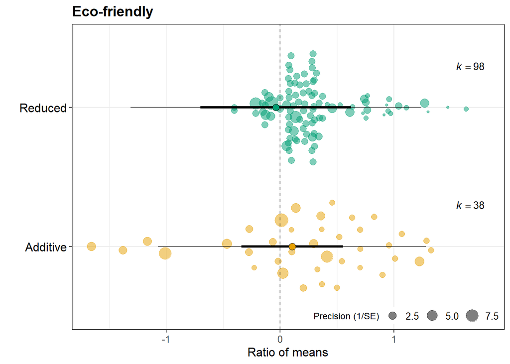

```r
Treatment_orch
```

```r
  # theme(text = element_text(size = 15),
  #       axis.text.y = element_text(size = 15))
```

## 5.3 Adding Mod; TREATMENT_DETAIL

```r
rom.Treatment_detail_mod <- rma.mv(
  yi,
  V,
  mods = ~ Treatment_detail_MOD - 1,
  random = list(~ 1 | Study,
                ~ 1 | Exp_ID,
                ~ 1 | Effect_ID,
                ~ 1 | Parameter),
  method = "REML",
  data = meta,
  control = list(optimizer = "optim")
)

sum_detail <- summary(rom.Treatment_detail_mod)

g_col <- c("grey","grey","grey","grey","grey","grey","grey","grey","grey","grey","grey","grey","grey")

Treatment_orch_detail_mod <-
  orchard_plot(rom.Treatment_detail_mod, mod = "Treatment_detail_MOD", xlab = "Ratio of means")+ scale_fill_manual(values = g_col) + scale_colour_manual(values = g_col) +  theme(axis.text.y = element_text(angle = 0, hjust = 1))
```

Plots with treatment detail included:

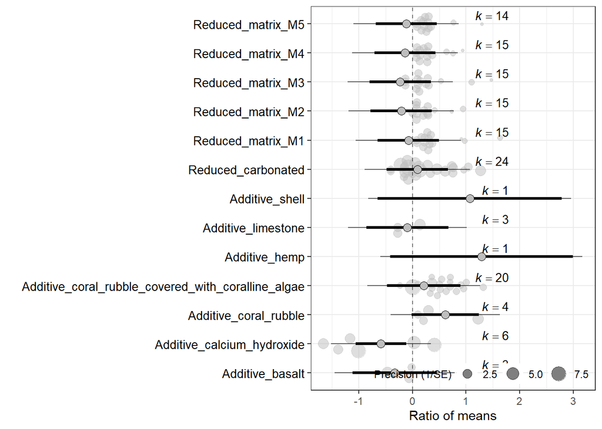

```r
Treatment_orch_detail_mod
```

## 5.4 Adding Mod: CONTROL

not needed as only concrete

## 5.5 Adding Mod: FUNCTIONAL GROUP

```r
rom.FunctionalGroup <- rma.mv(
  yi,
  V,
  mods = ~ FunctionalGroup - 1,
  random = list(~ 1 | Study,
                ~ 1 | Exp_ID,
                ~ 1 | Effect_ID,
                ~ 1 | Parameter),
  method = "REML",
  data = meta,
  control = list(optimizer = "optim")
)

sum <- summary(rom.FunctionalGroup)
sum_I2 <- i2_ml(rom.FunctionalGroup, method = "ns")
sum_R2 <- r2_ml(rom.FunctionalGroup)

res.FunctionalGroup <-
  data.frame(
    effectname = attr(sum$beta, "dimnames")[[1]],
    beta = as.numeric(sum$beta),
    percentage_increase_or_decrease_on_Ecofriendly = (exp(sum$beta) -
                                                        1) * 100,
    real.effect.value_exp_beta = exp(sum$beta),
    pval = sum$pval,
    ci.lb = sum$ci.lb,
    ci.ub = sum$ci.ub,
    I2_total = sum_I2[[1]] * 100,
    I2_study = sum_I2[[2]] * 100,
    I2_Exp_ID = sum_I2[[3]] * 100,
    I2_Effect_ID = sum_I2[[4]] * 100,
    I2_Parameter = sum_I2[[5]] * 100,
    R2_marginal_fixed = sum_R2[[1]] * 100,
    R2_conditional_fixed_random = sum_R2[[2]] * 100,
    Moderator_significance_stat = sum$QM,
    Moderator_significance_pval = sum$QMp,
    AIC = rom.FunctionalGroup$fit.stats$REML[3]
  )

res_FunctionalGroup_df <- bind_rows(res.FunctionalGroup)
write.csv(res_FunctionalGroup_df, file = "./outputs/eco_friendly/summ_FunctionalGroup.csv")

FunctionalGroup_orch <-
  orchard_plot(rom.FunctionalGroup, mod = "FunctionalGroup", xlab = "Ratio of means")
ggsave(FunctionalGroup_orch, file = "./outputs/eco_friendly/FunctionalGroup_orch.tiff", dpi = plot_dpi)

FunctionalGroup_cat <-
  caterpillars(rom.FunctionalGroup, mod = "FunctionalGroup", xlab = "Ratio of means")
ggsave(FunctionalGroup_cat, file = "./outputs/eco_friendly/FunctionalGroup_cat.tiff", dpi = plot_dpi)

# checking contrasts:
summary(glht(
  rom.FunctionalGroup,
  linfct = c(
    "FunctionalGroupBenthic - FunctionalGroupInvertebrate = 0",
    "FunctionalGroupBenthic - FunctionalGroupSessile = 0",
    "FunctionalGroupInvertebrate - FunctionalGroupSessile = 0"
  )
))
```

Summary of results:

```r
res.FunctionalGroup %>%
  kable("html", digits = 3) %>%
  kable_styling("striped", position = "left") %>%
  scroll_box(width = "100%",
             height = "100%")
```

|  | effectname | beta | percentage_increase_or_decrease_on_Ecofriendly | real.effect.value_exp_beta | pval | ci.lb | ci.ub | I2_total | I2_study | I2_Exp_ID | I2_Effect_ID | I2_Parameter | R2_marginal_fixed | R2_conditional_fixed_random | Moderator_significance_stat | Moderator_significance_pval | AIC |
| --- | --- | --- | --- | --- | --- | --- | --- | --- | --- | --- | --- | --- | --- | --- | --- | --- | --- |
| FunctionalGroupBenthic | FunctionalGroupBenthic | 0.358 | 43.059 | 1.431 | 0.423 | -0.518 | 1.234 | 68.58 | 36.305 | 25.218 | 5.92 | 1.137 | 14.519 | 98.582 | 1.95 | 0.583 | 181.765 |
| FunctionalGroupInvertebrate | FunctionalGroupInvertebrate | 0.111 | 11.742 | 1.117 | 0.655 | -0.376 | 0.598 | 68.58 | 36.305 | 25.218 | 5.92 | 1.137 | 14.519 | 98.582 | 1.95 | 0.583 | 181.765 |
| FunctionalGroupSessile | FunctionalGroupSessile | -0.259 | -22.788 | 0.772 | 0.423 | -0.892 | 0.375 | 68.58 | 36.305 | 25.218 | 5.92 | 1.137 | 14.519 | 98.582 | 1.95 | 0.583 | 181.765 |

Plot for functional group

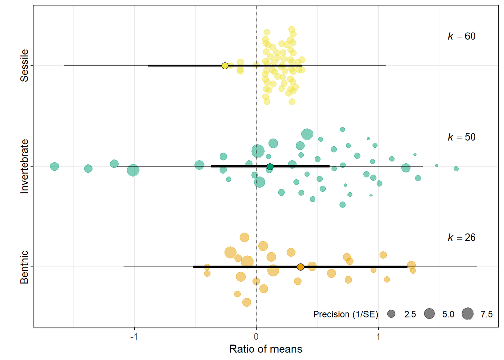

```r
FunctionalGroup_orch
```

```r
  # theme(text = element_text(size = 15),
  #       axis.text.y = element_text(size = 15))
```

## 5.6 Adding Mod: DURATION

```r
# DURATION CONTIN NEEDS TRANSFORMED.. BEST IS +1 then LOG
#Log Duraation has zeros.. therefore PLUS 1 first
#checking the transform:
# qqnorm(meta$Durationmonths)
# qqline(meta$Durationmonths)
# qqnorm(sqrt(meta$Durationmonths))
# qqline(sqrt(meta$Durationmonths))
# qqnorm(log10(meta$Durationmonths))
# qqline(log10(meta$Durationmonths))
# qqnorm(log10(meta$Durationmonths+1)) #best
# qqline(log10(meta$Durationmonths+1)) #best

#continuous - LOG10 DURATION
#Continuous moderator can't have -1 - as we don't want to remove the intercept
# for a slope. Therefore leave intercept in for this set of models.

rom.Duration <- rma.mv(
  yi,
  V,
  mods = ~ log10(Durationmonths + 1),
  random = list(~ 1 | Study,
                ~ 1 | Exp_ID,
                ~ 1 | Effect_ID,
                ~ 1 | Parameter),
  method = "REML",
  data = meta,
  control = list(optimizer = "optim")
)


sum <- summary(rom.Duration)
sum_I2 <- i2_ml(rom.Duration, method = "ns")
sum_R2 <- r2_ml(rom.Duration)

res.Duration <-
  data.frame(
    effectname = attr(sum$beta, "dimnames")[[1]],
    beta = as.numeric(sum$beta),
    percentage_increase_or_decrease_on_Ecofriendly = (exp(sum$beta)-1)*100,
    real.effect.value_exp_beta = exp(sum$beta),
    pval = sum$pval,
    ci.lb = sum$ci.lb,
    ci.ub = sum$ci.ub,
    I2_total = sum_I2[[1]] * 100,
    I2_study = sum_I2[[2]] * 100,
    I2_Exp_ID = sum_I2[[3]] * 100,
    I2_Effect_ID = sum_I2[[4]] * 100,
    I2_Parameter = sum_I2[[5]] * 100,
    R2_marginal_fixed = sum_R2[[1]] * 100,
    R2_conditional_fixed_random = sum_R2[[2]] * 100,
    Moderator_significance_stat = sum$QM,
    Moderator_significance_pval = sum$QMp,
    AIC = rom.Duration$fit.stats$REML[3]
  )

res_Duration_df <- bind_rows(res.Duration)
write.csv(res_Duration_df, file = "./outputs/eco_friendly/summ_Duration.csv")


#####
## PLot of Duration - Bubble plot
#####

#A scatter plot of log duration and effect size.
#Using the predict.rma function, which requires a model (rma.mv)
# Examples from:
# Hayward et al 2021. DOI: 10.1111/ele.13757. A broadscale analysis of host-symbiont
# cophylogeny reveals the drivers of phylogenetic congruence

# to get the precision on this plot, ie 1/SE.. we need SE.. and for SE we need N.
# SE is then sqrt(var/N)

# We have separate N's for the control and the treatment, they are partitioned.
#SO first we need to work out the highest N in each case, and use that as the
# Total N.

meta$Replicates <-
  pmax(meta$ReplicatesTreatment, meta$ReplicatesControl)

pred_Durationmonths <- predict.rma(rom.Duration)

# plotting

fig_Durationmonths <-  meta %>%
  filter(!is.na(Durationmonths))  %>% # getting ride of NA values
  data.frame(
    .,
    ymin = pred_Durationmonths$ci.lb,
    ymax = pred_Durationmonths$ci.ub,
    ymin2 = pred_Durationmonths$cr.lb,
    ymax2 = pred_Durationmonths$cr.ub,
    pred = pred_Durationmonths$pred
  ) %>%
  ggplot(aes(
    x = log10(Durationmonths + 1),
    y = yi,
    #yi = effect size
    size = 1 / sqrt(vi / Replicates),
    # precision: 1/SE /was (1 / yi) + 3 - which doesn't make sense.
    # we can use sample size N (ie number of replicates)
  )) +
  geom_point(shape = 21, fill = "grey90") +
  #geom_ribbon(aes(ymin = ymin, ymax = ymax), fill = "#0072B2")  + # not quite sure why this does not work
  geom_smooth(
    aes(y = ymin2),
    method =  "loess",
    se = FALSE,
    lty =  "dotted",
    lwd = 0.25,
    colour = "#0072B2"
  ) +
  geom_smooth(
    aes(y = ymax2),
    method =  "loess",
    se = FALSE,
    lty = "dotted",
    lwd = 0.25,
    colour = "#0072B2"
  ) +
  geom_smooth(
    aes(y = ymin),
    method =  "loess",
    se = FALSE,
    lty = "dotted",
    lwd = 0.25,
    colour = "#D55E00"
  ) +
  geom_smooth(
    aes(y = ymax),
    method =  "loess",
    se = FALSE,
    lty = "dotted",
    lwd = 0.25,
    colour = "#D55E00"
  ) +
  geom_smooth(
    aes(y = pred),
    method =  "loess",
    se = FALSE,
    lty = "dashed",
    lwd = 0.5,
    colour = "black"
  ) +
  #ylim(-1, 2) + xlim(-0.05, 2) +
  #geom_abline(intercept = mr_Duration..months.$beta[[1]], slope = mr_Duration..months.$beta[[2]], alpha = 0.7, linetype = "dashed", size = 0.5) +
  labs(x = "log(Duration (months))",
       y = expression(paste(italic(yi), " (effect size)")),
       size = expression(paste(italic(1 / se), " (precision)"))) +
  guides(fill = "none", colour = "none") +
  # themes
  theme_bw() +
  theme(legend.position = c(1, 1),
        legend.justification = c(1, 1)) +
  theme(legend.direction = "horizontal") +
  #theme(legend.background = element_rect(fill = "white", colour = "black")) +
  theme(legend.background = element_blank()) +
  theme(axis.text.y = element_text(
    size = 10,
    colour = "black",
    hjust = 0.5,
    angle = 90
  ))

fig_Durationmonths
```

```r
ggsave(filename = "./outputs/eco_friendly/Bubble_duration.tiff", dpi = plot_dpi)
```

Summary of results:

```r
res.Duration %>%
  kable("html", digits = 3) %>%
  kable_styling("striped", position = "left") %>%
  scroll_box(width = "100%",
             height = "100%")
```

|  | effectname | beta | percentage_increase_or_decrease_on_Ecofriendly | real.effect.value_exp_beta | pval | ci.lb | ci.ub | I2_total | I2_study | I2_Exp_ID | I2_Effect_ID | I2_Parameter | R2_marginal_fixed | R2_conditional_fixed_random | Moderator_significance_stat | Moderator_significance_pval | AIC |
| --- | --- | --- | --- | --- | --- | --- | --- | --- | --- | --- | --- | --- | --- | --- | --- | --- | --- |
| intrcpt | intrcpt | 0.234 | 26.309 | 1.263 | 0.314 | -0.221 | 0.688 | 65.006 | 31.625 | 26.913 | 6.456 | 0.011 | 1.956 | 99.983 | 1.596 | 0.206 | 184.828 |
| log10(Durationmonths + 1) | log10(Durationmonths + 1) | -0.234 | -20.857 | 0.791 | 0.206 | -0.597 | 0.129 | 65.006 | 31.625 | 26.913 | 6.456 | 0.011 | 1.956 | 99.983 | 1.596 | 0.206 | 184.828 |

Plot for Duration

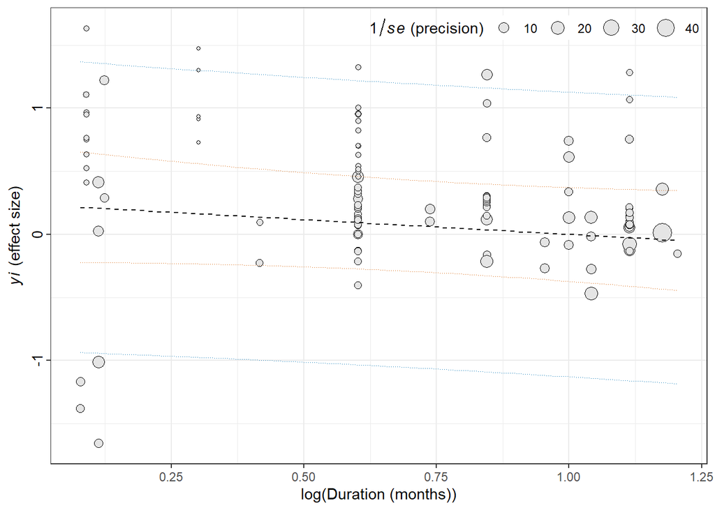

```r
fig_Durationmonths
```

```r
  # theme(text = element_text(size = 15),
  #       axis.text.y = element_text(size = 15))
```

## 5.7 Adding Mod: Year (timeline bias)

```r
# Year
#checking the transform:
# qqnorm(meta$Year)
# qqline(meta$Year)
# qqnorm(sqrt(meta$Year))
# qqline(sqrt(meta$Year))
# qqnorm(log10(meta$Year))
# qqline(log10(meta$Year))
# qqnorm(log10(meta$Year+1))
# qqline(log10(meta$Year+1))
#the transformationss don't change the data much, so leaving as is. ie- no transformtion


rom.Year <- rma.mv(yi, V, mods = ~ scale(Year),
                          random = list( ~1|Study,
                                    ~1|Exp_ID,
                                    ~1|Effect_ID,
                                    ~1|Parameter),
                          method="REML",
                          data=meta,
                          control = list(optimizer="optim"))


sum <- summary(rom.Year)
sum_I2 <- i2_ml(rom.Year, method = "ns")
sum_R2 <- r2_ml(rom.Year)

res.Year <- data.frame(
  effectname = attr(sum$beta, "dimnames")[[1]],
  beta = as.numeric(sum$beta),
  percentage_increase_or_decrease_on_Ecofriendly = (exp(sum$beta) -
                                                      1) * 100,
  real.effect.value_exp_beta = exp(sum$beta),
  pval = sum$pval,
  ci.lb = sum$ci.lb,
  ci.ub = sum$ci.ub,
  I2_total = sum_I2[[1]] * 100,
  I2_study = sum_I2[[2]] * 100,
  I2_Exp_ID = sum_I2[[3]] * 100,
  I2_Effect_ID = sum_I2[[4]] * 100,
  I2_Parameter = sum_I2[[5]] * 100,
  R2_marginal_fixed = sum_R2[[1]] * 100,
  R2_conditional_fixed_random = sum_R2[[2]] * 100,
  Moderator_significance_stat = sum$QM,
  Moderator_significance_pval = sum$QMp,
  AIC = rom.Year$fit.stats$REML[3]
)

res_Year_df <- bind_rows(res.Year)
write.csv(res_Year_df, file = "./outputs/eco_friendly/summ_Year.csv")

#####
## PLot of Year - Bubble plot
#####

#A scatter plot of log duration and effect size.
#Using the predict.rma function, which requires a model (rma.mv)
# Examples from file:///C:/Users/MQ45014051/OneDrive%20-%20Macquarie%20University/PhD/16_Meta_Analysis_Materials/Working/Analysis/Shinichi/electronic-supplementary-materials.html
# to get the precision on this plot, ie 1/SE.. we need SE.. and for SE we need N.
# SE is then sqrt(var/N)

pred_Year<- predict.rma(rom.Year)

# plotting

fig_year <-  meta %>%
  data.frame(
    .,
    ymin = pred_Year$ci.lb,
    ymax = pred_Year$ci.ub,
    ymin2 = pred_Year$cr.lb,
    ymax2 = pred_Year$cr.ub,
    pred = pred_Year$pred
  ) %>%
  ggplot(aes(
    x = Year,
    y = yi,                     #yi = effect size
    size = 1/sqrt(vi/Replicates),        # precision: 1/SE /was (1 / yi) + 3 - which doesn't make sense.
                                # we can use sample size N (ie number of replicates)

  )) +
  geom_point(shape = 21, fill = "grey90") +
  #geom_ribbon(aes(ymin = ymin, ymax = ymax), fill = "#0072B2")  + # not quite sure why this does not work
  geom_smooth(
    aes(y = ymin2),
    method =  "loess",
    se = FALSE,
    lty =  "dotted",
    lwd = 0.25,
    colour = "#0072B2"
  ) +
  geom_smooth(
    aes(y = ymax2),
    method =  "loess",
    se = FALSE,
    lty = "dotted",
    lwd = 0.25,
    colour = "#0072B2"
  ) +
  geom_smooth(
    aes(y = ymin),
    method =  "loess",
    se = FALSE,
    lty = "dotted",
    lwd = 0.25,
    colour = "#D55E00"
  ) +
  geom_smooth(
    aes(y = ymax),
    method =  "loess",
    se = FALSE,
    lty = "dotted",
    lwd = 0.25,
    colour = "#D55E00"
  ) +
  geom_smooth(
    aes(y = pred),
    method =  "loess",
    se = FALSE,
    lty = "dashed",
    lwd = 0.5,
    colour = "black"
  ) +
  #ylim(-1, 2) + xlim(-0.05, 2) +
  #geom_abline(intercept = mr_Year$beta[[1]], slope = mr_Year.$beta[[2]], alpha = 0.7, linetype = "dashed", size = 0.5) +
  labs(x = "Publication Year",
       y = expression(paste(italic(yi), " (effect size)")),
       size = expression(paste(italic(1/se), " (precision)"))) +
  guides(fill = "none", colour = "none") +
  # themes
  theme_bw() +
  theme(legend.position = c(1, 1),
        legend.justification = c(1, 1)) +
  theme(legend.direction = "horizontal") +
  #theme(legend.background = element_rect(fill = "white", colour = "black")) +
  theme(legend.background = element_blank()) +
  theme(axis.text.y = element_text(
    size = 10,
    colour = "black",
    hjust = 0.5,
    angle = 90
  ))

fig_year  # looks good - no obvious divergence
```

```r
ggsave(filename = "./outputs/eco_friendly/Bubble_year.tiff", dpi = plot_dpi)
```

Summary of results:

```r
res.Year %>%
  kable("html", digits = 3) %>%
  kable_styling("striped", position = "left") %>%
  scroll_box(width = "100%",
             height = "100%")
```

|  | effectname | beta | percentage_increase_or_decrease_on_Ecofriendly | real.effect.value_exp_beta | pval | ci.lb | ci.ub | I2_total | I2_study | I2_Exp_ID | I2_Effect_ID | I2_Parameter | R2_marginal_fixed | R2_conditional_fixed_random | Moderator_significance_stat | Moderator_significance_pval | AIC |
| --- | --- | --- | --- | --- | --- | --- | --- | --- | --- | --- | --- | --- | --- | --- | --- | --- | --- |
| intrcpt | intrcpt | 0.122 | 12.942 | 1.129 | 0.51 | -0.241 | 0.484 | 62.107 | 23.883 | 30.633 | 7.589 | 0.002 | 6.311 | 99.997 | 1.217 | 0.27 | 183.773 |
| scale(Year) | scale(Year) | 0.133 | 14.169 | 1.142 | 0.27 | -0.103 | 0.368 | 62.107 | 23.883 | 30.633 | 7.589 | 0.002 | 6.311 | 99.997 | 1.217 | 0.27 | 183.773 |

Plot for publication year

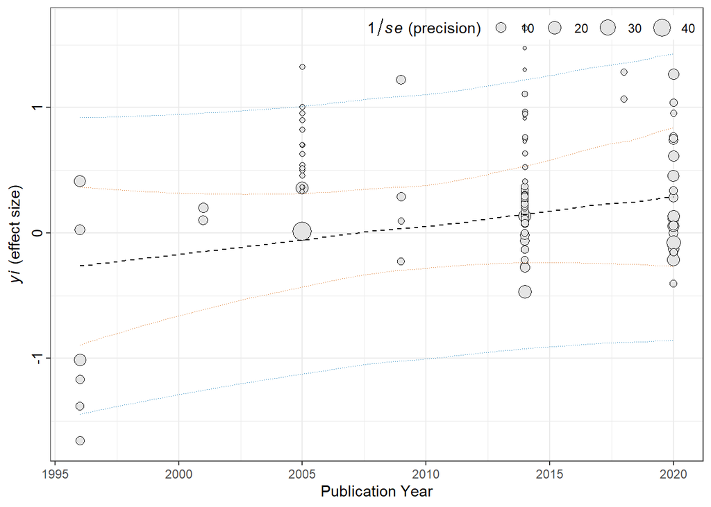

```r
fig_year
```

```r
  # theme(text = element_text(size = 15),
  #       axis.text.y = element_text(size = 15))
```

## 5.8 Adding Mod ALL MODERATORS

```r
rom.All <- rma.mv(
  yi,
  V,
  mods = ~ Treatment +
    FunctionalGroup +
    log10(Durationmonths + 1) +
    scale(Year),
  random = list(~ 1 | Study,
                ~ 1 | Exp_ID,
                ~ 1 | Effect_ID,
                ~ 1 | Parameter),
  method = "REML",
  data = meta,
  control = list(optimizer = "optim")
)


sum <- summary(rom.All)
sum_I2 <- i2_ml(rom.All, method = "ns")
sum_R2 <- r2_ml(rom.All)


res.All <- data.frame(
  effectname = attr(sum$beta, "dimnames")[[1]],
  beta = as.numeric(sum$beta),
  percentage_increase_or_decrease_on_Ecofriendly = (exp(sum$beta) - 1) *
    100,
  real.effect.value_exp_beta = exp(sum$beta),
  pval = sum$pval,
  ci.lb = sum$ci.lb,
  ci.ub = sum$ci.ub,
  I2_total = sum_I2[[1]] * 100,
  I2_study = sum_I2[[2]] * 100,
  I2_Exp_ID = sum_I2[[3]] * 100,
  I2_Effect_ID = sum_I2[[4]] * 100,
  I2_Parameter = sum_I2[[5]] * 100,
  R2_marginal_fixed = sum_R2[[1]] * 100,
  R2_conditional_fixed_random = sum_R2[[2]] * 100,
  Moderator_significance_stat = sum$QM,
  Moderator_significance_pval = sum$QMp,
  AIC = rom.All$fit.stats$REML[3]
)

res.All <- bind_rows(res.All)
write.csv(res.All, file = "./outputs/eco_friendly/summ_All.csv")
```

Summary of results:

```r
res.All %>%
  kable("html", digits = 3) %>%
  kable_styling("striped", position = "left") %>%
  scroll_box(width = "100%",
             height = "100%")
```

|  | effectname | beta | percentage_increase_or_decrease_on_Ecofriendly | real.effect.value_exp_beta | pval | ci.lb | ci.ub | I2_total | I2_study | I2_Exp_ID | I2_Effect_ID | I2_Parameter | R2_marginal_fixed | R2_conditional_fixed_random | Moderator_significance_stat | Moderator_significance_pval | AIC |
| --- | --- | --- | --- | --- | --- | --- | --- | --- | --- | --- | --- | --- | --- | --- | --- | --- | --- |
| intrcpt | intrcpt | 0.637 | 89.116 | 1.891 | 0.372 | -0.762 | 2.037 | 66.484 | 31.791 | 28.133 | 5.939 | 0.621 | 15.465 | 99.211 | 5.221 | 0.389 | 178.138 |
| TreatmentReduced | TreatmentReduced | -0.465 | -37.156 | 0.628 | 0.517 | -1.870 | 0.941 | 66.484 | 31.791 | 28.133 | 5.939 | 0.621 | 15.465 | 99.211 | 5.221 | 0.389 | 178.138 |
| FunctionalGroupInvertebrate | FunctionalGroupInvertebrate | 0.020 | 1.987 | 1.020 | 0.980 | -1.490 | 1.530 | 66.484 | 31.791 | 28.133 | 5.939 | 0.621 | 15.465 | 99.211 | 5.221 | 0.389 | 178.138 |
| FunctionalGroupSessile | FunctionalGroupSessile | -0.168 | -15.459 | 0.845 | 0.786 | -1.381 | 1.046 | 66.484 | 31.791 | 28.133 | 5.939 | 0.621 | 15.465 | 99.211 | 5.221 | 0.389 | 178.138 |
| log10(Durationmonths + 1) | log10(Durationmonths + 1) | -0.280 | -24.446 | 0.756 | 0.166 | -0.677 | 0.116 | 66.484 | 31.791 | 28.133 | 5.939 | 0.621 | 15.465 | 99.211 | 5.221 | 0.389 | 178.138 |
| scale(Year) | scale(Year) | 0.309 | 36.249 | 1.362 | 0.137 | -0.099 | 0.717 | 66.484 | 31.791 | 28.133 | 5.939 | 0.621 | 15.465 | 99.211 | 5.221 | 0.389 | 178.138 |

## 5.9 Full model comparisons

Testing the robustness of all moderators.

```r
# https://stat.ethz.ch/pipermail/r-sig-mixed-models/2014q3/022608.html
# Viechtbauer, W. (2007). Accounting for heterogeneity via random-effects
# > models and moderator analyses in meta-analysis. Zeitschrift für
# > Psychologie / Journal of Psychology, 215(2), 104-121.
#https://stat.ethz.ch/pipermail/r-help/2011-August/285943.html
#
# explanation of tests of factors:
# http://www.metafor-project.org/doku.php/tips:testing_factors_lincoms

#summary(rom.All.noint)
summary(rom.All)
```

```
##
## Multivariate Meta-Analysis Model (k = 136; method: REML)
##
##   logLik  Deviance       AIC       BIC      AICc
## -79.0691  158.1383  178.1383  206.8136  179.9870
##
## Variance Components:
##
##             estim    sqrt  nlvls  fixed     factor
## sigma^2.1  0.1509  0.3884      9     no      Study
## sigma^2.2  0.1335  0.3654     39     no     Exp_ID
## sigma^2.3  0.0282  0.1679    136     no  Effect_ID
## sigma^2.4  0.0029  0.0543      2     no  Parameter
##
## Test for Residual Heterogeneity:
## QE(df = 130) = 268.2858, p-val < .0001
##
## Test of Moderators (coefficients 2:6):
## QM(df = 5) = 5.2214, p-val = 0.3895
##
## Model Results:
##
##                              estimate      se     zval    pval    ci.lb   ci.ub
## intrcpt                        0.6372  0.7141   0.8923  0.3722  -0.7624  2.0368
## TreatmentReduced              -0.4645  0.7172  -0.6477  0.5172  -1.8702  0.9412
## FunctionalGroupInvertebrate    0.0197  0.7705   0.0255  0.9796  -1.4905  1.5299
## FunctionalGroupSessile        -0.1679  0.6191  -0.2712  0.7862  -1.3814  1.0455
## log10(Durationmonths + 1)     -0.2803  0.2023  -1.3858  0.1658  -0.6768  0.1162
## scale(Year)                    0.3093  0.2082   1.4854  0.1374  -0.0988  0.7175
##
## intrcpt
## TreatmentReduced
## FunctionalGroupInvertebrate
## FunctionalGroupSessile
## log10(Durationmonths + 1)
## scale(Year)
##
## ---
## Signif. codes:  0 '***' 0.001 '**' 0.01 '*' 0.05 '.' 0.1 ' ' 1
```

```r
#
# treatment
summary(rom.Treatment)
```

```
##
## Multivariate Meta-Analysis Model (k = 136; method: REML)
##
##   logLik  Deviance       AIC       BIC      AICc
## -86.0593  172.1187  184.1187  201.5057  184.7801
##
## Variance Components:
##
##             estim    sqrt  nlvls  fixed     factor
## sigma^2.1  0.1536  0.3919      9     no      Study
## sigma^2.2  0.1246  0.3529     39     no     Exp_ID
## sigma^2.3  0.0312  0.1765    136     no  Effect_ID
## sigma^2.4  0.0005  0.0217      2     no  Parameter
##
## Test for Residual Heterogeneity:
## QE(df = 134) = 278.5303, p-val < .0001
##
## Test of Moderators (coefficients 1:2):
## QM(df = 2) = 0.2239, p-val = 0.8941
##
## Model Results:
##
##                    estimate      se     zval    pval    ci.lb   ci.ub
## TreatmentAdditive    0.1045  0.2278   0.4588  0.6464  -0.3420  0.5510
## TreatmentReduced    -0.0389  0.3376  -0.1152  0.9083  -0.7005  0.6228
##
## ---
## Signif. codes:  0 '***' 0.001 '**' 0.01 '*' 0.05 '.' 0.1 ' ' 1
```

```r
anova(rom.All, btt = 2)
```

```
##
## Test of Moderators (coefficient 2):
## QM(df = 1) = 0.4195, p-val = 0.5172
```

```r
#-> remains non-significant in full model

# functional group
summary(rom.FunctionalGroup)
```

```
##
## Multivariate Meta-Analysis Model (k = 136; method: REML)
##
##   logLik  Deviance       AIC       BIC      AICc
## -83.8823  167.7645  181.7645  201.9970  182.6605
##
## Variance Components:
##
##             estim    sqrt  nlvls  fixed     factor
## sigma^2.1  0.1838  0.4287      9     no      Study
## sigma^2.2  0.1277  0.3573     39     no     Exp_ID
## sigma^2.3  0.0300  0.1731    136     no  Effect_ID
## sigma^2.4  0.0058  0.0759      2     no  Parameter
##
## Test for Residual Heterogeneity:
## QE(df = 133) = 278.4683, p-val < .0001
##
## Test of Moderators (coefficients 1:3):
## QM(df = 3) = 1.9500, p-val = 0.5829
##
## Model Results:
##
##                              estimate      se     zval    pval    ci.lb   ci.ub
## FunctionalGroupBenthic         0.3581  0.4468   0.8014  0.4229  -0.5176  1.2338
## FunctionalGroupInvertebrate    0.1110  0.2487   0.4465  0.6552  -0.3763  0.5984
## FunctionalGroupSessile        -0.2586  0.3231  -0.8004  0.4235  -0.8919  0.3747
##
## FunctionalGroupBenthic
## FunctionalGroupInvertebrate
## FunctionalGroupSessile
##
## ---
## Signif. codes:  0 '***' 0.001 '**' 0.01 '*' 0.05 '.' 0.1 ' ' 1
```

```r
anova(rom.All, btt = 3:4)
```

```
##
## Test of Moderators (coefficients 3:4):
## QM(df = 2) = 0.2324, p-val = 0.8903
```

```r
#-> remains non-significant in full model

#duration
summary(rom.Duration)
```

```
##
## Multivariate Meta-Analysis Model (k = 136; method: REML)
##
##   logLik  Deviance       AIC       BIC      AICc
## -86.4142  172.8284  184.8284  202.2154  185.4898
##
## Variance Components:
##
##             estim    sqrt  nlvls  fixed     factor
## sigma^2.1  0.1437  0.3791      9     no      Study
## sigma^2.2  0.1223  0.3497     39     no     Exp_ID
## sigma^2.3  0.0293  0.1713    136     no  Effect_ID
## sigma^2.4  0.0001  0.0072      2     no  Parameter
##
## Test for Residual Heterogeneity:
## QE(df = 134) = 276.3228, p-val < .0001
##
## Test of Moderators (coefficient 2):
## QM(df = 1) = 1.5965, p-val = 0.2064
##
## Model Results:
##
##                            estimate      se     zval    pval    ci.lb   ci.ub
## intrcpt                      0.2336  0.2320   1.0068  0.3140  -0.2211  0.6882
## log10(Durationmonths + 1)   -0.2339  0.1851  -1.2635  0.2064  -0.5968  0.1289
##
## intrcpt
## log10(Durationmonths + 1)
##
## ---
## Signif. codes:  0 '***' 0.001 '**' 0.01 '*' 0.05 '.' 0.1 ' ' 1
```

```r
anova(rom.All, btt = 5)
```

```
##
## Test of Moderators (coefficient 5):
## QM(df = 1) = 1.9204, p-val = 0.1658
```

```r
#-> remains non-significant in full model

#year
summary(rom.Year)
```

```
##
## Multivariate Meta-Analysis Model (k = 136; method: REML)
##
##   logLik  Deviance       AIC       BIC      AICc
## -85.8866  171.7733  183.7733  201.1603  184.4347
##
## Variance Components:
##
##             estim    sqrt  nlvls  fixed     factor
## sigma^2.1  0.1002  0.3166      9     no      Study
## sigma^2.2  0.1286  0.3586     39     no     Exp_ID
## sigma^2.3  0.0319  0.1785    136     no  Effect_ID
## sigma^2.4  0.0000  0.0030      2     no  Parameter
##
## Test for Residual Heterogeneity:
## QE(df = 134) = 280.4870, p-val < .0001
##
## Test of Moderators (coefficient 2):
## QM(df = 1) = 1.2172, p-val = 0.2699
##
## Model Results:
##
##              estimate      se    zval    pval    ci.lb   ci.ub
## intrcpt        0.1217  0.1848  0.6585  0.5102  -0.2405  0.4839
## scale(Year)    0.1325  0.1201  1.1033  0.2699  -0.1029  0.3679
##
## ---
## Signif. codes:  0 '***' 0.001 '**' 0.01 '*' 0.05 '.' 0.1 ' ' 1
```

```r
anova(rom.All, btt = 6)
```

```
##
## Test of Moderators (coefficient 6):
## QM(df = 1) = 2.2063, p-val = 0.1374
```

```r
#-> remains non-significant in full model
```

# 6 PUBLICATION BIAS

This is important for testing whether only significant results were published.If this s the case, the results can be skewed in favour of significant results and create false positives or negatives - i.e. you’re not getting the full picture. This can be tested visually using a Funnel plot and then quantitatively using a trim and fill method. Both of the methods assume independence between effect sizes. If this is not the case, then the residuals from the full model can be used.

Funnel plot shows the effect size on the x axis and a measure of precision of the observed effect size on the y axis.

funnel() has std error on y by default.

Only significant moderators are included.

## 6.1 Funnel Plots

```r
#simple model
jpeg("./outputs/eco_friendly/funnel_simple.jpg",
     width = 600,
     height = 600)
par(cex = 1.4)
funnel(
  rom.simple,
  yaxis = "sei",
  level = c(90, 95, 99),
  shade = c("white",
            "gray55", "gray75"),
  refline = 0,
  legend = TRUE
)
dev.off()

#No full model as none of the moderators significant
```

## 6.2 Eggers Regression (significance of publication bias)

```r
### Eggers regression to test significance of publication bias (no intercept)
# testing whether any asymmetries in the funnel plots are significant

#Simple model
egger_reg_simple <- rma.mv (
  yi,
  V,
  mods = ~ sqrt(vi),
  random = list(~ 1 | Study,
                ~ 1 | Exp_ID,
                ~ 1 | Effect_ID,
                ~ 1 | Parameter),
  method = "REML",
  data = meta,
  control = list(optimizer = "optim")
)

summary(egger_reg_simple)
```

[output not shown]

# 7 SUMMARIES

## 7.1 Combined summary table

Creating a summary table of all the results summaries

```r
#get list of summaries
summaries <- mget(ls(pattern = "(res[^_])"))
#[^_] = NOT underscore (ie avoiding underscores)
summaries_df <- bind_rows(summaries, .id = "name")

write.csv(summaries_df, file = "./outputs/eco_friendly/eco_friendly_results.csv")
```